Vamsi Gudipati

Portfolio · Reduced-order models and digital twins · October 2026

# From modes to a twin: reduced-order models of a heated plate, and a hybrid digital twin of a steel ladle built on the same basis

Fifteen POD modes carry a 2,304-unknown heat-conduction solver to 1.4 % error inside its sampled box, seventy times faster, and both the projected and the regressed model fail at the box's edge in different ways. The same backbone, eight modes on a gas-stirred ladle, turns 16 thermocouples and a gas-flow reading into the whole temperature field: a physics core that misses a third of the field becomes a hybrid that misses a fifth, tying a pure-data map and beating a network. Eight sensors placed by the modes beat the sixteen on the lances, and a guard on the readings detects a drift at a third of its size, if it is calibrated at the plant's real noise.

**Vamsi Gudipati** Proper orthogonal decomposition · Reduced-order models · Hybrid twins · Sensor placement [Repository](https://github.com/vamsigudipati/rom-ladle-digital-twin)

1.42 ± 0.08 %

intrusive ROM error inside the box, 15 modes for 2,304 unknowns (3 draws)

×74, 51 queries

speed-up over the solver, and the queries that repay the build

33 % → 19 %

share of the ladle field missed: physics core alone, then the hybrid twin

0.188 vs 0.192

hybrid twin against the pure-data ridge map, a tie over 3 seeds

8 at the pivots

sensors that beat the twin's 16 thermocouples; random placement needs 24

## Objective

A simulation that is fine for one analysis becomes the bottleneck when a design sweep, an uncertainty study, a controller or a digital twin calls it thousands of times. A reduced-order model answers the same question for a whole family of inputs at a fraction of the cost, resting on one observation: the fields such a family produces are variations on a theme, so a handful of shared spatial patterns describe all of them. I wanted to follow that idea from a textbook case, where I know the answer, into something a plant could use, and to find out where it stops working. The work is three stages, each a notebook:

1. **Stage 1 — POD reduced-order models, intrusive and data-driven.** A plate heated by a Gaussian source whose position is the input. The solver has 2,304 unknowns; proper orthogonal decomposition (POD) compresses its solutions into 15 modes, and two reduced models are built on them, one that projects the solver's own operator and one that only regresses input to coefficients. Both are then broken on purpose: outside the sampled box and with a variable they were never shown.
2. **Stage 2 — A hybrid digital twin of a gas-stirred ladle.** The same backbone on an industrial question: the full temperature field of a gas-stirred steel ladle from 16 thermocouples and the gas-flow reading. A physics core, the core corrected by a learned residual (the hybrid twin), a pure-data soft sensor and a small network are compared, three plant numbers are read off, and a guard flags fields the basis cannot represent.
3. **Stage 3 — Sensors and the guard under stress.** Stress tests on that twin: how many sensors it needs and where to put them, and how its guard behaves as the plant drifts towards an abnormal regime and as the sensors get noisier.

Wherever a result depends on a random draw (the sampled source positions, the thermocouple noise, the network's initial weights, the random sensor layouts) it is repeated with three seeds, and seed 0 is always the base run. There is no external data: Stage 1's reference is its own finite-difference solver, and the ladle fields come from an analytic generator, so every error is against a known truth, and every error is optimistic for the same reason.

## Problem statement

Stage 1 asks: how few numbers does a family of solutions need, how good is a model that lives on those numbers, when does it repay its build, and what happens at the edge of the family? Stage 2 asks the question a plant asks: given the few numbers I can measure, what is the whole field, which decisions can I take from it, and when should I not trust it? Stage 3 asks what the modes themselves say about the sensors: where to measure, how many readings, and how to tell when a heat has left the family.

[figure not shown]

**One method through three stages.** A trusted model gives a family of fields; POD turns it into a few modes; two routes compute in that space; the twin adds a correction, sensors chosen from the modes, and a guard calibrated apart. Orange: the two headline results of Stage 3, medians over three seeds.

[figure not shown]

**How the stages connect.** No file passes between Stage 1 and Stage 2: the twin recomputes its own basis from its own generator, and what carries over is the method. Stage 3 reads the generator (`ladle_v2.py`) and rebuilds the twin's data, basis and split from Stage 2's code.

[figure not shown]

**What is held out, in each stage.** Left: the source position of Stage 1, with the training box, the slightly smaller test box, the corner used to leave the box and the wider source. Right: the 620 heats of the ladle in plant-time order; the twin fits on heats 0 to 299 and is scored on 375 to 499; heats 300 to 374, unused by the twin, are where Stage 3 calibrates its guard.

## Method

### A basis from snapshots, and two ways to use it

Forty solves of the plate at random source positions, each stored every ten of its 300 time steps, give 1,200 snapshots in a 2,304 × 1,200 matrix. Its singular value decomposition orders the shared spatial patterns by how much of the snapshots they carry; the 15th singular value is 1.08 % of the first, and the first 15 modes reconstruct a held-out field to 1.14 %. Everything that follows works on 15 coefficients instead of 2,304 temperatures.

[figure not shown]

**The intrusive route.** The backward-Euler step matrix of the solver, 2,304 × 2,304, is projected to a 15 × 15 operator that is inverted once; each query projects its source, steps 15 numbers 300 times and lifts the result back.

[figure not shown]

**The non-intrusive route.** One hundred final fields are projected to 100 × 15 targets; a degree-4 polynomial ridge map takes the source position to 15 coefficients, with no access to the solver's internals.

The intrusive model needs the solver's matrices and keeps the physics; the data-driven one needs only input–output pairs and can be built on a black-box solver. Both are tested on 40 new positions inside the box, then taken outside it along a diagonal sweep to the far corner, and given a source twice as wide, a variable neither was built to see.

### The ladle: physics gives the structure, data fill the gap

The generator produces 620 heats of a 96 × 64 temperature field from six smooth drivers (the gas-flow plume, wall and floor boundary layers, a slag layer, stratification, recirculation tilt, fill level) that drift slowly in plant time, with a late abnormal double-plume regime. Only the gas flow and the wall cooling are known to the twin; the rest must come from 16 thermocouples on two lances with 2 K noise. The POD basis here is volume-weighted, because the cells of a cylindrical ladle are not the same size, and 8 modes keep 99.1 % of the training energy.

[figure not shown]

**Three maps from 17 readings to 8 coefficients.** The physics core evaluates the generator with the hidden drivers at their training means. The hybrid twin adds to it a residual field, learned by a ridge map from the readings in a residual basis. The soft sensor skips the core and maps readings straight to the field basis; a 17–64–8 network does the same job with GELU activations.

[figure not shown]

**Offline once, online per heat.** Offline, the 300 training heats give the mean field, the modes, the residual basis and the ridge maps. Online, a heat's 17 readings become 8 coefficients, lifted back to a 6,144-cell field and scored against the true field it never sees.

### Sensors from the modes

Stage 3 places sensors by the pivots of a QR factorisation of the mode matrix (the DEIM rule): the cells where the modes are most distinguishable. With m sensors, gappy POD solves a least-squares problem for the coefficients with no training at all, and a ridge map does the same with training. Random layouts drawn with the same seeds are the reference. For the guard, a fraction α of the abnormal double-plume structure is added to the normal test heats, and Gaussian noise of 0 to 10 % of each thermocouple's signal is added to the readings, with the thresholds set on heats the twin never uses.

## Implementation

What was run, and with what.

[output not shown]

## Results 1 — Fifteen numbers instead of 2,304 (Stage 1)

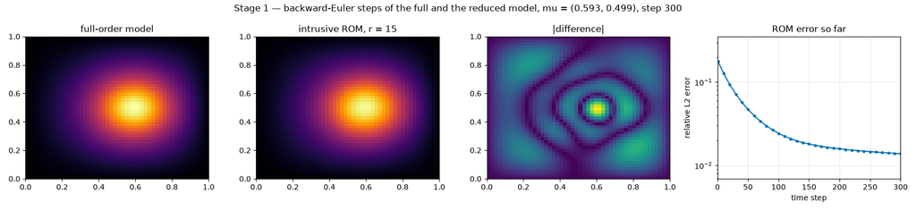

**The full model and the rank-15 intrusive model stepping side by side** on one test position, with the error field and the relative error so far. After 300 steps the reduced model is 1.38 % from the full one; at the first step it was 17.6 %, because the transient's earliest shape is the hardest for a basis built from later snapshots.

Relative L2 errors against the full solver; the first value is the base draw, the bracket the three draws of the source positions.

| Quantity | Value |
| --- | --- |
| Unknowns, full solver / reduced | 2,304 / 15 |
| Rank-15 projection of a held-out field | 1.14 % (1.06 ± 0.18 % over 3 draws) |
| Intrusive ROM, 40 test positions | 1.51 % (1.42 ± 0.08 %) |
| Non-intrusive ROM, 40 test positions | 4.57 % (4.52 ± 0.04 %) |
| 40 queries: solver / intrusive ROM | 959 / 13 ms, ×74 |
| Offline build (40 solves + SVD) | 1.21 s |
| Break-even | about 51 queries |

Inside the box both models work and the spread across draws is small. The intrusive model sits only a little above the projection error, which is the best any 15-mode basis can do; the regression leaves three times more, because it has to learn the map from position to coefficients rather than inherit it from the operator.

The speed-up is real but the build is not free: 40 queries do not yet repay the 1.21 s of solves and SVD, about 51 do. A query of the reduced model costs 0.33 ms against 24 ms for the solver.

[figure not shown]

**Error against rank.** The intrusive error falls with the rank along the singular values; at rank 15 it sits a little above the projection of a held-out field.

[figure not shown]

**Cumulative time against the number of queries.** The solver alone against the intrusive model with its offline build; the timed batch of 40 queries is short of break-even.

### Where the family ends

[figure not shown]

**Inside the box both models are accurate and stable across draws; far outside it both fail; a wider source defeats only the regression.** Violet: intrusive; orange: non-intrusive. Bars are means over three draws, lines one standard deviation, logarithmic scale.

Three draws of the positions; the corner and wide-source fields are the same in every draw.

| Case | Intrusive | Non-intrusive |
| --- | --- | --- |
| In the box, 40 positions | 1.42 ± 0.08 % | 4.52 ± 0.04 % |
| Far corner (0.05, 0.05) | 75.9 ± 1.2 % | 2,696 ± 173 % |
| Source twice as wide (w = 0.18) | 0.53 ± 0.17 % | 68.1 ± 0.03 % |
| Sweep position where the error passes 5 % | t = 0.48 ± 0.04 (just outside) | t = 0.24 ± 0.11 (inside) |

Taken to the far corner, the intrusive model degrades to 76 % and the polynomial explodes to twenty-seven times the field. A source twice as wide is a variable neither model was given: the intrusive model, which still steps the real operator with the real source, barely notices (0.5 %); the regression, which only ever saw the position, answers as if the source were narrow and misses by 68 %.

The two failures are different in kind. Outside the sampled positions the basis itself is the limit, and both models hit it; an unmodelled variable is invisible only to the model that never touches the physics.

[figure not shown]

**Three regressors on the same coefficients.** A thin-plate-spline radial basis map beats the polynomial in the box (1.42 % against 4.57 %) and fails less badly at the corner; a small network adds nothing (4.70 ± 0.23 %).

[figure not shown]

The ROM's error has shape, not noise: the error field at the edge of the box is a structured pattern, and a structured error can be learned. That observation is what Stage 2 builds on.

## Results 2 — A hybrid twin of a steel ladle (Stage 2)

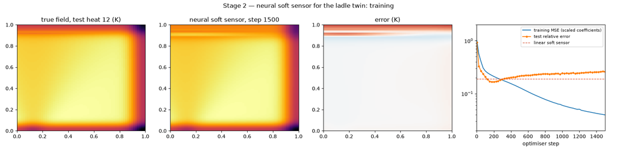

**The neural soft sensor's training, on one test heat.** True field, the network's field after 1,500 steps, its error in kelvin, and the training loss with the test error against the ridge map's, which the network ends above.

[figure not shown]

**The hybrid twin and the ridge soft sensor tie; both halve the physics core's error; the network is worse for every seed.** Bars: the mean of three seeds; dots: the single runs; open dot: the base run.

125 test heats, later in plant time than every fit.

| Model | Share of the variation missed (3 seeds) |
| --- | --- |
| Physics core alone | 0.334 |
| Hybrid twin (core + learned residual) | 0.188 ± 0.003 |
| Ridge soft sensor | 0.192 ± 0.002 (4.52 ± 0.05 K RMS) |
| Neural soft sensor | 0.238 ± 0.022 |

The physics core with the hidden drivers at their means misses a third of the variation. A residual learned from 17 readings in an 8-mode basis brings the hybrid to 19 %, and so does a pure-data ridge map with no physics at all. The hybrid is lower for each of the three seeds, by 0.004, a gap of one and a half to two standard deviations that three runs cannot establish: I report it as a close tie, not as a win for the physics.

[figure not shown]

**The network overfits.** Its test error is lowest at step 175 (0.166, below the ridge map's 0.190) and ends at 0.261 after 1,500 steps while the training loss keeps falling.

[figure not shown]

**Wall load and superheat come back tightly, stratification does not.** R² of the three plant numbers from the ridge soft sensor's field on the 125 test heats, three seeds.

The network, with 1,672 parameters, does worse than a linear map with 144, and not by a little: 0.238 ± 0.022 against 0.192 ± 0.002, worse on every seed. It would have beaten the ridge map had it stopped at step 175, which is an argument for early stopping, not for the network. The R² values of 0.896 ± 0.011 for superheat, 0.951 ± 0.008 for wall load and 0.720 ± 0.030 for stratification say that the twin is decision-grade for two of its three numbers; stratification lives near the surface, which few probes see.

## Results 3 — Sensors and the guard under stress (Stage 3)

### How many sensors, and where

[figure not shown]

**Field error against the number of sensors, for pivot and random placement.** Left: gappy POD, no training. Middle: the ridge map from readings and gas flow. Right: the condition number of the sampled modes. Lines are medians over three seeds, bands the smallest to largest; values above 10 are drawn at 10.

Share of the variation missed on the 125 test heats, 2 K noise; the twin's own 16 probes on two lances reach 0.189 with the same ridge map.

| Sensors m | Pivots, gappy POD | Pivots, ridge map | Random, ridge map (median) |
| --- | --- | --- | --- |
| 2 | 0.999 | 1.04 | 0.885 |
| 4 | 0.914 | 0.565 | 0.707 |
| 6 | 0.603 | 0.337 | 0.596 |
| 8 | 0.143 | 0.134 | 0.640 [0.32, 0.79] |
| 16 | 0.127 | 0.132 | 0.223 |
| 24 | — | — | 0.122 |
| 32 | 0.125 | 0.131 | 0.125 |

The knee sits exactly at the number of modes. Below 8 pivots gappy POD is useless (0.603 with 6); at 8 it drops to 0.143 with no training at all, and the ridge map to 0.134, better than the twin's 16 thermocouples on their two lances. Above 8, more sensors buy almost nothing: the floor near 0.125 is what 8 modes can represent.

Random placement is a different story. Gappy POD fails outright, with condition numbers up to 1e15, until 16, 24 or 32 sensors depending on the draw; the trained ridge map never fails but needs about 24 random sensors to match 8 at the pivots. Placement matters more than count.

### The guard, as the plant drifts and the sensors get noisier

[figure not shown]

**Detection against drift, and the soft sensor and guard against noise.** Left: share of test heats flagged as a fraction α of the abnormal structure is added. Middle: the ridge soft sensor's error against noise. Right: the sensor-space guard against noise, with its threshold set without noise and recalibrated at each level.

Share of the 125 test heats flagged; thresholds at the 99th percentile over heats 300–374. On the twin's own abnormal heats: field guard 92.5 %, sensor guard 100 %.

| Drift α | Field guard (true field) | Sensor guard, 1 % noise |
| --- | --- | --- |
| 0 | 0 % | 0 % |
| 0.1 | 0 % | 8.0 % [2.4, 8.8] |
| 0.2 | 0 % | 67.2 % [61.6, 75.2] |
| 0.3 | 0.8 % | 96.0 % [94.4, 96.8] |
| 0.5 | 3.2 % | 100 % |
| 1 (the full abnormal structure) | 59.2 % | 100 % |

Noise as a share of each thermocouple's signal standard deviation; recalibrated, false alarms stay at 0 at every level.

| Noise | Soft sensor error | False alarms, threshold set without noise | Abnormal heats found, recalibrated |
| --- | --- | --- | --- |
| 0 % | 0.122 | 0 | 1.00 |
| 1 % | 0.122 ± 0.001 | every normal heat | 1.00 |
| 5 % | 0.150 ± 0.001 | every normal heat | 0.81 ± 0.03 |
| 10 % | 0.175 | every normal heat | 0.24 ± 0.06 |

A guard that scores the readings themselves, the share of the 16 readings' energy that the sampled modes cannot fit, detects the drift far earlier than the twin's own guard on the true field: 96 % of heats at 30 % of the abnormal structure, where the field guard flags under 1 % and reaches only 59 % at full size, because its score is normalised by the whole field's variation. Neither guard raises a false alarm on a normal heat.

But the sensor guard is only as good as its calibration. Set on noise-free readings, it flags every normal heat from 1 % noise on; set at each noise level, it raises no false alarm and still finds every abnormal heat at 1 %, 81 % of them at 5 % and 24 % at 10 %. The soft sensor itself degrades gently, from 0.122 to 0.175, which is 2.9 to 4.1 K over the bath. A twin like this would need its alarm threshold set at the plant's real noise before it ran, and that noise, the twin's own 2 K, lies above the range I tested.

## Key observations

1. **A basis is a family, and the family has an edge.** Fifteen modes carry a 2,304-unknown plate to 1.4 % inside the sampled box and 76 % at the far corner; eight modes carry the ladle to a floor near 0.125 that no number of sensors gets under.
2. **Physics in the loop fails gracefully; data alone fails loudly.** The projected operator degrades to 76 % outside the box and barely notices a variable it was never shown (0.5 %); the regression explodes to 2,700 % and misses the unseen variable by 68 %. In the ladle the physics core alone is the worst model (33 %), and the physics corrected by data ties the data alone (19 %).
3. **A structured error can be learned.** The plate ROM's error has shape; the same idea, a residual in its own 8-mode basis, halves the ladle core's error. What it does not do, with three seeds, is beat a ridge map that skips the physics: 0.188 ± 0.003 against 0.192 ± 0.002 is a tie I would not sell as a win.
4. **The simplest model that works is the one to keep.** A 144-parameter linear map beats a 1,672-parameter network on every seed, and a network that would have won at step 175 loses at step 1,500. In Stage 1 a thin-plate spline beats the polynomial and a network adds nothing.
5. **The modes say where to measure.** Eight sensors at the QR pivots beat the twin's 16 thermocouples on two lances (0.134 against 0.189), and random placement needs three times as many. The knee is at the number of modes, which is a rule a plant could use.
6. **A guard is a calibration, not a formula.** Moved onto the readings, the guard detects drift at 30 % of its size instead of 100 %; set at the wrong noise level, it flags every normal heat. The threshold must be set on heats the twin never uses, at the noise the plant actually has.

## Conclusion

One method serves both settings. A POD basis compresses the plate to 15 numbers and the ladle to 8; on it, a projected model and a learned map both work inside the family, and the same basis, applied to a physics model's error, turns a 33 % core into a 19 % hybrid. The twin's question, which 17 numbers to measure, is decided by the basis as much as by the regression, and its guard works on the readings a plant has, provided it is calibrated on separate heats at the real noise.

What the stages do not establish: the data are analytic, a sum of six smooth patterns close to the span of 8 modes by construction, so every error is optimistic; the drift is the abnormal structure scaled, not another kind of fault, and a slowly drifting thermocouple was not tested; the pivots are cells anywhere in the bath away from the border, and whether a probe can be placed there was not considered; and noise above 10 % of each signal, where the twin's own 2 K lies, was not run. The next steps are a simulation or plant dataset in place of the generator, a field error on the abnormal heats rather than only a detection rate, the guard at the twin's own noise, and a projection error of the test heats printed apart from the maps' error so that the floor near 0.125 is computed, not read off a plot.

## Code, data and reproducibility

The three notebooks of the repository, each also exported as HTML with all outputs.

| Notebook | Stage |
| --- | --- |
| `01_pod_rom_intrusive_and_data_driven.ipynb` | Stage 1 — POD reduced-order models, intrusive and data-driven |
| `02_ladle_hybrid_digital_twin.ipynb` with `ladle_v2.py` | Stage 2 — A hybrid digital twin of a gas-stirred ladle |
| `03_sensors_and_guard.ipynb` | Stage 3 — Sensors and the guard under stress |

| Item | Where |
| --- | --- |
| Repository | vamsigudipati/rom-ladle-digital-twin: the three executed notebooks, the ladle generator, result tables and figures for every experiment and seed, the soft-sensor checkpoints and the two animations |
| Data | None external: Stage 1 solves its own finite-difference problem, and the ladle fields come from the analytic generator `ladle_v2.py` in the repository |
| Environment | `requirements.txt` in the repository (Python 3.12, NumPy 2.5, SciPy 1.18, scikit-learn 1.8, PyTorch 2.14) |
| Run | Everything runs on a laptop CPU in under two minutes; every number reproduces exactly on a re-run |